# Logistic Regression from Scratch

**DAN HARGREAVES** - DATA SCIENCE PORTFOLIO

## LOGISTIC REGRESSION MODEL USING GRADIENT DESCENT FROM SCRATCH

In this project we will build a logistic regression algorithm from scratch using Gradient Descent and use this algorithm to create a model that determines the likelihood of shot success for LA Lakers' shooting guard Kobe Bryant.

We will clean and process the data using Pandas but will build the algorithm from scratch with Numpy before comparing with the pre-built Sci-Kit Learn logistic regression algorithm.

The data we will use is from the Kobe Bryant Kaggle competition. The goal in this competition was to predict shot success for records in the data that had a NULL shot_made_flag field. As we are using this dataset to build and test a custom built algorithm to compare with a pre-built algorithm then we will exlude the NULL values. In addition we will only use shot distance and combined shot type as our model features.

## IMPORT LIBRARIES & DATA

```python
import pandas as pd
import os
import matplotlib.pyplot as plt
import seaborn as sns
import numpy as np
import warnings
warnings.filterwarnings('ignore')
```

```python
data = pd.read_csv('data.csv')
```

## EXPLORE DATA

```python
data.describe()
```

|  | game_event_id | game_id | lat | loc_x | loc_y | lon | minutes_remaining | period | playoffs | seconds_remaining | shot_distance | shot_made_flag | team_id | shot_id |
| --- | --- | --- | --- | --- | --- | --- | --- | --- | --- | --- | --- | --- | --- | --- |
| count | 30697.000000 | 3.069700e+04 | 30697.000000 | 30697.000000 | 30697.000000 | 30697.000000 | 30697.000000 | 30697.000000 | 30697.000000 | 30697.000000 | 30697.000000 | 25697.000000 | 3.069700e+04 | 30697.000000 |
| mean | 249.190800 | 2.476407e+07 | 33.953192 | 7.110499 | 91.107535 | -118.262690 | 4.885624 | 2.519432 | 0.146562 | 28.365085 | 13.437437 | 0.446161 | 1.610613e+09 | 15349.000000 |
| std | 150.003712 | 7.755175e+06 | 0.087791 | 110.124578 | 87.791361 | 0.110125 | 3.449897 | 1.153665 | 0.353674 | 17.478949 | 9.374189 | 0.497103 | 0.000000e+00 | 8861.604943 |
| min | 2.000000 | 2.000001e+07 | 33.253300 | -250.000000 | -44.000000 | -118.519800 | 0.000000 | 1.000000 | 0.000000 | 0.000000 | 0.000000 | 0.000000 | 1.610613e+09 | 1.000000 |
| 25% | 110.000000 | 2.050008e+07 | 33.884300 | -68.000000 | 4.000000 | -118.337800 | 2.000000 | 1.000000 | 0.000000 | 13.000000 | 5.000000 | 0.000000 | 1.610613e+09 | 7675.000000 |
| 50% | 253.000000 | 2.090035e+07 | 33.970300 | 0.000000 | 74.000000 | -118.269800 | 5.000000 | 3.000000 | 0.000000 | 28.000000 | 15.000000 | 0.000000 | 1.610613e+09 | 15349.000000 |
| 75% | 368.000000 | 2.960047e+07 | 34.040300 | 95.000000 | 160.000000 | -118.174800 | 8.000000 | 3.000000 | 0.000000 | 43.000000 | 21.000000 | 1.000000 | 1.610613e+09 | 23023.000000 |
| max | 659.000000 | 4.990009e+07 | 34.088300 | 248.000000 | 791.000000 | -118.021800 | 11.000000 | 7.000000 | 1.000000 | 59.000000 | 79.000000 | 1.000000 | 1.610613e+09 | 30697.000000 |

```python
data.info()
```

```
<class 'pandas.core.frame.DataFrame'>
RangeIndex: 30697 entries, 0 to 30696
Data columns (total 25 columns):
action_type           30697 non-null object
combined_shot_type    30697 non-null object
game_event_id         30697 non-null int64
game_id               30697 non-null int64
lat                   30697 non-null float64
loc_x                 30697 non-null int64
loc_y                 30697 non-null int64
lon                   30697 non-null float64
minutes_remaining     30697 non-null int64
period                30697 non-null int64
playoffs              30697 non-null int64
season                30697 non-null object
seconds_remaining     30697 non-null int64
shot_distance         30697 non-null int64
shot_made_flag        25697 non-null float64
shot_type             30697 non-null object
shot_zone_area        30697 non-null object
shot_zone_basic       30697 non-null object
shot_zone_range       30697 non-null object
team_id               30697 non-null int64
team_name             30697 non-null object
game_date             30697 non-null object
matchup               30697 non-null object
opponent              30697 non-null object
shot_id               30697 non-null int64
dtypes: float64(3), int64(11), object(11)
memory usage: 5.9+ MB
```

```python
data.head()
```

|  | action_type | combined_shot_type | game_event_id | game_id | lat | loc_x | loc_y | lon | minutes_remaining | period | ... | shot_type | shot_zone_area | shot_zone_basic | shot_zone_range | team_id | team_name | game_date | matchup | opponent | shot_id |
| --- | --- | --- | --- | --- | --- | --- | --- | --- | --- | --- | --- | --- | --- | --- | --- | --- | --- | --- | --- | --- | --- |
| 0 | Jump Shot | Jump Shot | 10 | 20000012 | 33.9723 | 167 | 72 | -118.1028 | 10 | 1 | ... | 2PT Field Goal | Right Side(R) | Mid-Range | 16-24 ft. | 1610612747 | Los Angeles Lakers | 2000-10-31 | LAL @ POR | POR | 1 |
| 1 | Jump Shot | Jump Shot | 12 | 20000012 | 34.0443 | -157 | 0 | -118.4268 | 10 | 1 | ... | 2PT Field Goal | Left Side(L) | Mid-Range | 8-16 ft. | 1610612747 | Los Angeles Lakers | 2000-10-31 | LAL @ POR | POR | 2 |
| 2 | Jump Shot | Jump Shot | 35 | 20000012 | 33.9093 | -101 | 135 | -118.3708 | 7 | 1 | ... | 2PT Field Goal | Left Side Center(LC) | Mid-Range | 16-24 ft. | 1610612747 | Los Angeles Lakers | 2000-10-31 | LAL @ POR | POR | 3 |
| 3 | Jump Shot | Jump Shot | 43 | 20000012 | 33.8693 | 138 | 175 | -118.1318 | 6 | 1 | ... | 2PT Field Goal | Right Side Center(RC) | Mid-Range | 16-24 ft. | 1610612747 | Los Angeles Lakers | 2000-10-31 | LAL @ POR | POR | 4 |
| 4 | Driving Dunk Shot | Dunk | 155 | 20000012 | 34.0443 | 0 | 0 | -118.2698 | 6 | 2 | ... | 2PT Field Goal | Center(C) | Restricted Area | Less Than 8 ft. | 1610612747 | Los Angeles Lakers | 2000-10-31 | LAL @ POR | POR | 5 |

5 rows × 25 columns

#### REMOVE NULLS

The Kaggle competition involved attempting to predict values for the NULLs values in the shot_made_flag field so to train and test our model we can drop these records

```python
data.dropna(inplace=True)
```

## VISUALISATIONS

For our model we will use combined_shot_type and distance as our features. Both fields show significant variance in shot success depending on the fields value.

#### COMBINED SHOT TYPE

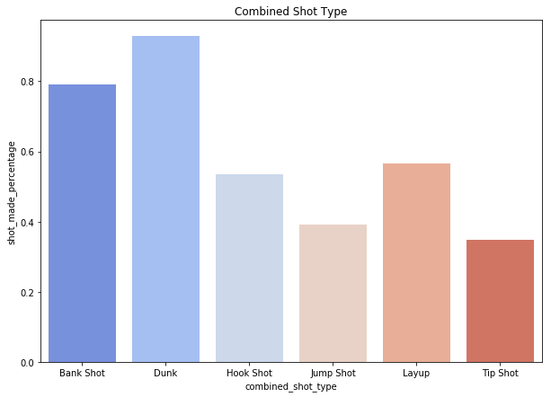

```python
group = data.groupby(['combined_shot_type'],as_index=False)['shot_made_flag'].agg(['sum','count']).reset_index()
group['shot_made_percentage'] = group['sum']/group['count']
plt.figure(figsize=(10,7))
plt.title('Combined Shot Type')
sns.barplot(x="combined_shot_type", y="shot_made_percentage", data=group,palette="coolwarm")
```

#### SHOT DISTANCE

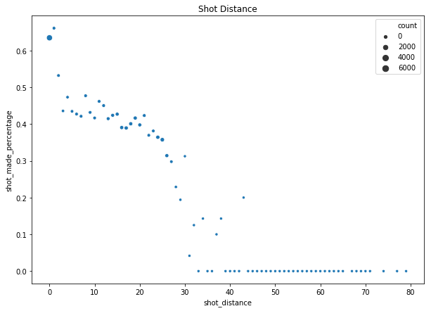

```python
group = data.groupby(['shot_distance'],as_index=False)['shot_made_flag'].agg(['sum','count']).reset_index()
group['shot_made_percentage'] = group['sum']/group['count']
plt.figure(figsize=(10,7))
plt.title('Shot Distance')
sns.scatterplot(x='shot_distance', y='shot_made_percentage', data=group,  size='count')
```

#### CHECK TARGET IS BALANCED

We need to ensure that there is reasonable split of outcomes in the target variable to ensure that our model generalises well.

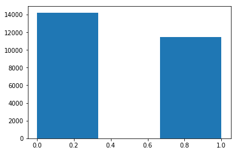

```python
plt.hist(data['shot_made_flag'],3)
plt.show()
```

## FEATURE ENGINEERING

#### CREATE DUMMY VARIABLES FOR COMBINED SHOT TYPE & SPLIT INTO FEATURES & TARGET

```python
comb_sht = pd.get_dummies(data['combined_shot_type'])
X = pd.concat([data[['shot_distance']],comb_sht],axis=1)
y = data['shot_made_flag']
```

#### SCALE SHOT DISTANCE

```python
max_dist = max(X['shot_distance'])
X['shot_distance'] = X['shot_distance']/max_dist
```

#### SPLIT DATA INTO TEST AND TRAINING SETS FOR BOTH FEATURES AND TARGET

```python
from sklearn.model_selection import train_test_split
X_train, X_test, y_train, y_test = train_test_split(X, y, test_size=0.4, random_state=101)
```

#### BENCHMARK VALUE

```python
y_train.sum() / y_train.count()
```

```
0.44733428460241276
```

Kobe Bryant was successful with 45% of shots therefore by predicting that he always misses we will be correct 55% of the time so we will use this as the benchmark to beat with our model.

#### CONVERT DATAFRAMES TO MATRICES FOR USE WITH NUMPY

```python
X_train = X_train.as_matrix()
X_test = X_test.as_matrix()
y_train = pd.DataFrame(y_train)
y_train = y_train.as_matrix()
y_test = pd.DataFrame(y_test)
y_test = y_test.as_matrix()
```

## CREATE TRAINING ALGORITHM

As we intend to build a logistic regression model, we will use the [Sigmoid Function](https://en.wikipedia.org/wiki/Sigmoid_function) as our hypothesis function where we will take the exponent to be the negative of a linear function g(x) that is comprised of our features represented by x<sub>0</sub>, x<sub>1</sub>... and associated feature weights w<sub>0</sub>, w<sub>1</sub>... (which will be found using gradient descent) to give g(x) = w<sub>0</sub>x<sub>0</sub> + w<sub>1</sub>x<sub>1</sub>....

Building the model will involve the following steps:

- Set inital feature weights
- Calculate cost for those weights using cost function for regularised logistic regression
- Perform [Gradient Descent](https://en.wikipedia.org/wiki/Gradient_descent) on all features simultaneously given a pre-defined learning rate to derive new feature weight set
- Calculate cost for new feature weights using cost function for regularised logistic regression
- Repeat the previous two steps for e number of epochs
- Use the set of feature weights that produce the minimum cost in the final model

#### Create Constant Term Feature

Insert column of 1s as weight for the constant term x<sub>0</sub>.

```python
X_0 = np.ones((len(X_train),1))
X_train = np.insert(X_train,[0],X_0, axis=1)
X_0 = np.ones((len(X_test),1))
X_test = np.insert(X_test,[0],X_0, axis=1)
```

#### Hypothesis Function

Function that returns an array that is the result of applying the sigmoid function to the dot product of the training features array and array of associated weights

```python
def hypothesis(X,w):
    w = np.array(w.reshape((8,1)))
    z = np.dot(X,w)
    h =  1 / (1 + np.exp(-1 * z))
    h = np.round(h)
    h = np.clip(h, 0.00001,0.99999)
    return h
```

#### Cost Function

Function that returns the cost for regularised logistic regression given training features X, target y, feature weights w, number of training examples m and regularisation term r

```python
#Cost function
def cost(X,y,w,m,r):
    h = hypothesis(X,w)
    c = (-1/m)*sum(y*np.log(h) + (1-y)*np.log(1-h)) + (r/(2*m))*sum(np.square(w))
    return c
```

#### Model Training Using Gradient Descent Function

Function to train model for training features X, target y given intial weights w, with number of training examples m, learning rate lr and regularisation term r for e number of epochs. The cost of each epoch will be printed if verbose is set to true otherwise just the model summary will be printed after training is complete.

```python
def train_model(X, y, w, m, lr, e, r, verbose=False):
    #Get cost for initial weights and set to current minimum cost,
    c = cost(X,y,w,m,r)
    cost_min = c
    #Set current optimum weights to inital weights
    optimum_weight = w
    epoch_min = 1
    #Perform gradient descent for e number of epochs
    for i in range(1,e):
        #Initlialise empty weights list for epoch i
        w_epoch = []
        #Calculate new weights for each feature j
        for j in range(0,len(w)):
            h = hypothesis(X,w)
            #New weight j
            w_j = w[j] - lr*(1/m)*sum((h - y)*X[:,[j]]) + (r/m)*w[j]
            #Append new weight to list of weights for epoch i
            w_epoch.append(w_j)
        #Assign epoch i weights as model weights
        w = np.array(w_epoch)
        #Calculate cost for new weights derived in epoch i
        c = cost(X,y,w,m,r)
        #If cost for the weights derived in this epoch are lower than the previous
        #lowest cost then set optimum_weight to this and min_cost to the cost
        if c < cost_min:
            optimum_weight = w
            cost_min = c
            epoch_min = i
        #Print cost of epoch if v set to True
        if verbose == True:
            print('epoch ' + str(i) + ': Cost=' + str(c))
    #Print model summary
    print('Final Summary:')
    print('Min cost: ' + str(cost_min))
    print('Minimum found at epoch ' + str(epoch_min))
    print('Optimum weights: ' + str(optimum_weight))
    #Return feature weights
    return optimum_weight
```

## TRAIN & TEST MODEL

#### Initalise Model Parameters

```python
learning_rate = 0.1
reg_term = 0.2
weights = np.zeros((8,1))
epochs = 500
m = len(X_train)
```

#### Train Model

```python
model = train_model(X_train, y_train, weights, m, learning_rate, epochs, reg_term)
```

```
Final Summary:
Min cost: [4.43328147]
Minimum found at epoch 239
Optimum weights: [[ 0.00913678]
 [-0.04253551]
 [ 0.01430432]
 [ 0.03734765]
 [-0.00540641]
 [-0.01503518]
 [-0.00571635]
 [-0.01635726]]
```

#### Predict Target for Training and Test Sets

```python
#Predict y_test using model
def pred(X,w):
    h = hypothesis(X,w)
    return h
y_train_pred = pred(X_train,model)
y_train_pred = np.round(y_train_pred)
y_test_pred = pred(X_test,model)
y_test_pred = np.round(y_test_pred)
```

#### Analyse Predictions

```python
from sklearn.metrics import classification_report, accuracy_score
print('Training Data Accuracy Score: ')
print(accuracy_score(y_train,y_train_pred))
print('\nTest Data Accuracy Score: ')
print(accuracy_score(y_test,y_test_pred))
print('\nTraining Data Classification Report: ')
print(classification_report(y_train,y_train_pred))
print('\nTest Data Classification Report: ')
print(classification_report(y_test,y_test_pred))
```

```
Training Data Accuracy Score:
0.6149306005967051

Test Data Accuracy Score:
0.616305088043584

Training Data Classification Report:
              precision    recall  f1-score   support

         0.0       0.61      0.85      0.71      8521
         1.0       0.64      0.32      0.43      6897

   micro avg       0.61      0.61      0.61     15418
   macro avg       0.62      0.59      0.57     15418
weighted avg       0.62      0.61      0.58     15418


Test Data Classification Report:
              precision    recall  f1-score   support

         0.0       0.61      0.85      0.71      5711
         1.0       0.64      0.32      0.43      4568

   micro avg       0.62      0.62      0.62     10279
   macro avg       0.62      0.59      0.57     10279
weighted avg       0.62      0.62      0.58     10279
```

## TRAIN & TEST SCI-KIT LEARN MODEL

#### Train Model & Predict Test Target

```python
from sklearn.linear_model import LogisticRegression
logmodel = LogisticRegression(solver='liblinear')
logmodel.fit(X_train,y_train)
predictions = logmodel.predict(X_test)
```

#### Sci-kit Prediction Analysis

```python
print('Sci-Kit Learn Model Accuracy Score: ')
print(accuracy_score(y_test,predictions))
print('\nSci-Kit Learn Model Classification Report: ')
print(classification_report(y_test,predictions))
```

```
Sci-Kit Learn Model Accuracy Score:
0.616596945228135

Sci-Kit Learn Model Classification Report:
              precision    recall  f1-score   support

         0.0       0.61      0.85      0.71      5711
         1.0       0.64      0.32      0.43      4568

   micro avg       0.62      0.62      0.62     10279
   macro avg       0.62      0.59      0.57     10279
weighted avg       0.62      0.62      0.59     10279
```

## CONCLUSION

As we can see the logistic regression model built using gradient descent from scratch performed extremely well compared to the sci-kit learn logistic regression model in this case, scoring only marginally behind the pre-built algorithm for both accuracy and weighted average f1 score. We could possibly improve the result of the model by tuning the parameters.

As a model for the given problem, we managed to marginally improve accruacy to 62% from the 55% derived from the benchmark based on overall shot success rate.